# Informe MiniProyecto 2025

Grupo F: Samantha Morata Sánchez, Xavi Ponsoda Langon, Arnau López Rodrigo, Jorge Cano Cortina y Àngela Adell Castell

**Introducción**

En este proyecto de la asignatura Tratamiento de los Datos del Grado Ciencia de Datos, se encomienda la tarea del estudio de los datos de uno de los supermercados líder en España: Mercadona. Para ello, han sido proporcionados una gran cantidad de tickets que han permitido un buen estudio del comportamiento del mercado y de sus clientes.

**Gestión de los datos**

Para la realización del MiniProyecto, ha sido necesario llevar a cabo un tratamiento previo de los tickets proporcionados, iniciando con su filtrado, ya que algunos de ellos no correspondían a Mercadona, sino a otros supermercados que no son relevantes para nuestro estudio.

Para el correcto estudio, se ha hecho uso de las siguientes librerías… Stringr para el majnejo de datos de tipo string. Dplyr para limpiar, resumir, ordenar y transformar datasets. Tidyverse para análisis de datos: importar, limpiar, transformar, visualizar y modelar. Lubridate para tratar fechas. Ggplot2 para la creación de gráficas.

A continuación, estos tickets han sido importados de un formato .pdf a un formato más manejable tipo .txt y posteriormente han sido procesados con RStudio y guardados en dos data frames para un correcto estudio de la información obtenida.

En el primer data frame, se ha guardado la información de cada compra y está referenciado en la variable ‘df_tickets’, el cual contiene la siguiente información: número de factura, direccion del establecimiento, fecha de compra, hora de compra, número de productos, importe de la compra, parking y método de pago. *Véase en la Figura 1.*

Figura 1: Información de los tickets de Mercadona

| factura | direccion | fecha | hora | n_productos | importe | parking | metodo_pago |
| --- | --- | --- | --- | --- | --- | --- | --- |
| 2916-010-520925 | CTRA. GARRUCHA A VERA S/N | 2023-11-25 | 09:09 | 14 | 37.76 | TRUE | tarjeta |
| 2233-011-451305 | AVDA. VALENCIA 41 | 2023-12-01 | 14:41 | 29 | 86.70 | FALSE | tarjeta |
| 2233-011-452354 | AVDA. VALENCIA 41 | 2023-12-05 | 20:44 | 25 | 58.00 | FALSE | tarjeta |
| 4530-017-211832 | C/ ALICANTE 83 | 2023-12-13 | 19:36 | 11 | 29.34 | FALSE | tarjeta |
| 2233-010-731651 | AVDA. VALENCIA 41 | 2023-12-15 | 15:21 | 1 | 3.20 | FALSE | tarjeta |
| 3075-010-680549 | C/ MENORCA (C.C. AQUA) 19 | 2023-12-18 | 18:56 | 21 | 60.47 | FALSE | tarjeta |

En el segundo data frame, se ha guardado la información de los productos de cada compra distinguiendo entre productos especiales que van al peso como por ejmeplo la fruta, la verdura o el pescado. Los productos quedan referenciados en la variable ‘df_productos’, la cual contiene la siguiente información: el número de factura de dónde se compró dicho producto, la cantidad del producto, el nombre del producto, el peso (si fuera un producto al peso), el precio por unidad y el precio total del producto. *Véase en la figura 2.*

Figura 2: Información de las compras en Mercadona

| factura | cantidad | nombre | precio_unitario | precio_total | peso | tipo |
| --- | --- | --- | --- | --- | --- | --- |
| 2916-010-520925 | 5 | DONACIÓN | 1.00 | 5.00 | NA | otro |
| 2916-010-520925 | 1 | BARREÑO | 2.20 | 2.20 | NA | otro |
| 2916-010-520925 | 3 | PALO ANTIDESLIZANTE | 1.90 | 5.70 | NA | otro |
| 2916-010-520925 | 1 | MULTIUSOS | 2.55 | 2.55 | NA | otro |
| 2916-010-520925 | 2 | AGUA MINERAL | 0.73 | 1.46 | NA | otro |
| 2916-010-520925 | 2 | B.BASURA EXT.C.FÁCIL | 1.60 | 3.20 | NA | otro |

**Preguntas**

A partir de estos data frames, haremos un análisis exploratorio para responder a algunas de las preguntas más comunes que uno se podría hacer cuando piensa en datos y características de un supermercado.

Dada la vista información, el profesor nos ha planteado las siguientes preguntas:

1. ¿Cuáles son los 5 productos, de los vendidos por unidades, con más ventas?

-Los 5 productos más vendidos por unidad son…

En primer lugar se encuentra el filete de pechuga, seguido en segundo lugar por el queso de cabra en lonchas. En tercer lugar se sitúa el queso Arzúa, en cuarto lugar el plátano y, finalmente, en quinto lugar, el pack de atún claro. *Véase en la Figura 3*

2. ¿Cuántas unidades de cada uno se han vendido?

-Se han registrado ventas de 153 unidades de filete de pechuga, así como 153 unidades de queso de cabra en lonchas. Asimismo, se han vendido 141 unidades de queso Arzúa, 132 unidades de plátano y 125 unidades de atún en aceite de oliva. *Véase en la Figura 3*

Figura 3: Top 5 productos más vendidos por unidad

| nombre | ventas_totales |
| --- | --- |
| FILETE PECHUGA | 153 |
| QUESO LONCHAS CABRA | 153 |
| QUESO ARZUA | 141 |
| PLATANO | 132 |
| ATÚN CLARO OLIVA PK | 125 |

3. ¿Cuáles son las 5 fruta/verdura más vendidas?

-Como podemos observar, el plátano es con diferencia la fruta más vendida, seguida por su hermana la banana. Luego tenemos pepino, berenjena y kiwi verde. Cabe destacar que estos son los PRODUCTOS más vendidos de esta sección, que no las frutas o verduras más vendidas ya que, por ejemplo, la manzana sería una de las más vendidas pero, al haber tantos tipos, ninguna de ellas alcanza el top. Es decir, hay muchas frutas y verduras que pueden haber sido más vendidas, pero ningún tipo concreto de estas llega a alcanzar a otras que no están seccionadas. *Véase en la Figura 4*

También hay que decir que hemos tenido en cuenta para este ranking las veces que han sido vendidos y no los kilos que han sido vendidos.

Figura 4: Top 5 verduras o frutas más venidas

| nombre | cantidad_total |
| --- | --- |
| PLATANO | 58 |
| BANANA | 25 |
| PEPINO | 24 |
| BERENJENA | 20 |
| KIWI VERDE | 20 |

4. ¿Cuántos kg se han vendido de estos productos?

-Obviamente, el plátano es el que más cantidad se ha comprado. Es interesante que todos los productos aquí se venden cerca de un kilo por vez. Algunos un poco más, otros un poco menos. Pero el kiwi se aleja de ese número un montón. Siendo la compra media de alrededor de un cuarto de kilo.*Figura 5*

Figura 5

| nombre | kilos_totales |
| --- | --- |
| PLATANO | 62.868 |
| BANANA | 28.140 |
| PEPINO | 19.624 |
| BERENJENA | 14.268 |
| KIWI VERDE | 6.312 |

5. ¿Cuáles son los 5 pescados más vendidos?

-Aquí tenemos los 5 tipos de pescado que han sido vendidos más veces. Aún así, han sido vendido pocas veces. Esto muestra, comparando con las dos preguntas anteriores, lo poco común que es la compra de pescado en comparativa de la de fruta y verdura.*Figura 6*

Figura 6: Top 5 pescados más venidos

| nombre | cantidad_total |
| --- | --- |
| BACALADILLA | 6 |
| SEPIA FRESCA | 5 |
| SEPIA LONJA | 5 |
| LENGUADO FRESC EUROP | 3 |
| SALMON ENTERO | 3 |

6. ¿Cuántos kg se han vendido de estos productos?

```
## # A tibble: 5 × 2
##   nombre               kilos_totales
##   <chr>                        <dbl>
## 1 BACALADILLA                   7.37
## 2 SALMON ENTERO                 4.57
## 3 SEPIA LONJA                   3.58
## 4 SEPIA FRESCA                  2.64
## 5 LENGUADO FRESC EUROP          1.25
```

-Observamos que el Salmón se vende en más cantidad por compra, esto es porque es entero.

7. Muestra mediante un gráfico de líneas como ha variado el precio por kilo de las bananas y los plátanos en los tickets disponibles, a lo largo del tiempo.
- La gráfica muestra la fluctuación del precio del kilo de los plátanos y las bananas, como se observa, el que más a variado de precio durante el tiempo es el kilo de plátano…*Véase en la Figura 7*

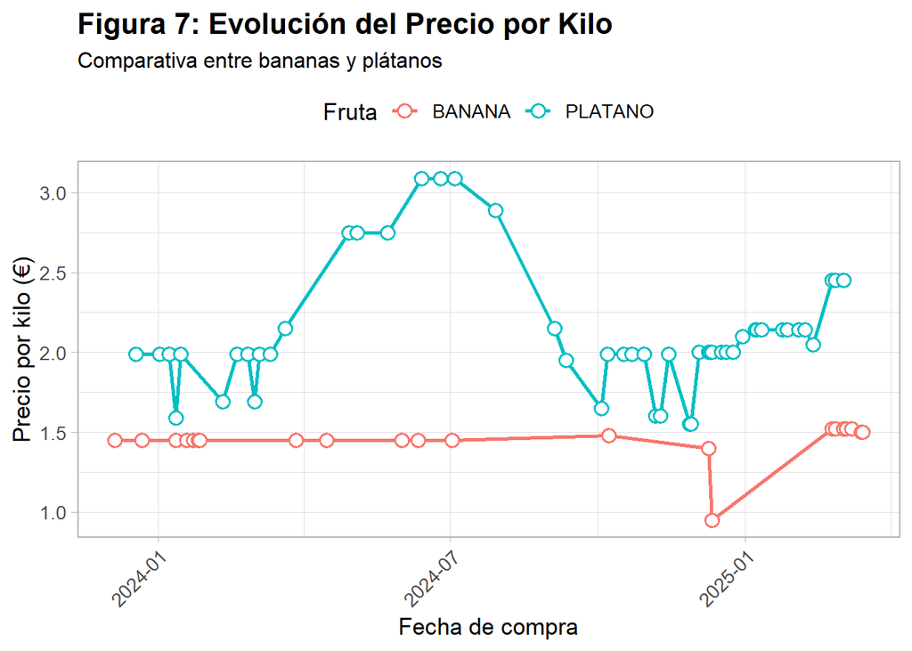

Nosotros hemos planteado las siguientes:

1. ¿Cuál es el gasto medio por compra?

-El gasto medio por compra es de 45.88€

```
## # A tibble: 6 × 8
## # Groups:   factura [6]
##   factura     direccion fecha      hora  n_productos importe parking metodo_pago
##   <chr>       <chr>     <date>     <chr>       <dbl>   <dbl> <lgl>   <fct>
## 1 2916-010-5… "       … 2023-11-25 09:09          14    37.8 TRUE    tarjeta
## 2 2233-011-4… "       … 2023-12-01 14:41          29    86.7 FALSE   tarjeta
## 3 2233-011-4… "       … 2023-12-05 20:44          25    58   FALSE   tarjeta
## 4 4530-017-2… "       … 2023-12-13 19:36          11    29.3 FALSE   tarjeta
## 5 2233-010-7… "       … 2023-12-15 15:21           1     3.2 FALSE   tarjeta
## 6 3075-010-6… "       … 2023-12-18 18:56          21    60.5 FALSE   tarjeta
```

```
## El gasto medio por compra es: 45.88152 €
```

-Como podemos observar, el mercadona que mas se ha visitado ha sido el que se encuentra en C/ QUART 120; el cual ha sido visitado un total de 51 veces.

Establecimiento más popular

| direccion | visitas |
| --- | --- |
| C/ QUART 120 | 51 |

4. ¿En qué parte del día es más común hacer la compra?

```
## # A tibble: 1 × 2
##   parte_dia total_compras
##   <fct>             <int>
## 1 Noche               114
```

-Como podemos observar, la parte del día donde es más común hacer la compra es durante la noche, que habiéndola definido como lo hemos hecho nosotros, es entre las 18 y las 21 horas. Esto tiene sentido, ya que coincide con la franja horaria en la que la gente sale de trabajar y por lo tanto tienen tiempo para ir al supermercado.

Franja del día más frecuentada

| parte_dia | total_compras |
| --- | --- |
| Noche | 114 |
| Mediodía | 81 |
| Tarde | 49 |
| Mañana | 30 |
| Madrugada | 16 |

5. ¿Cuál es el producto que, cuando se compra, se compra en mayor cantidad?

```
## # A tibble: 1 × 2
##   nombre           cantidad_media
##   <chr>                     <dbl>
## 1 COLA SIN CAFEINA              8
```

-Se observa que el producto que cuando se compra, se hace en mayor cantidad, es la cola sin cafeina, siendo así que cada vez que alguien compra este producto, de media compra 8 unidades.

```
## ventas_por_dia
##   domingo    jueves     lunes    martes miércoles    sábado   viernes
##         1        31        50        42        40        80        46
```

-Como podemos observar, el día de la semana que es más habitual hacer la compra, es decir, el día de la semana que más vende es el sábado. Esto tiene sentido, ya que muchas personas aprovechan el fin de semana para hacer la compra de la semana, y algunas también tienen libre ese día, lo que les permite ir con más comodidad al supermercado.

**Conclusión**

En esta primera fase del proyecto, hemos aprendido a importar documentos .pdf así como almacenar de forma iterativa en data frames información de ficheros .txt. Además, hemos ampliado nuestro conocimeinto sobre librerías como stringr, tidyverse o dplyr y hemos aprendido el funcionamiento de la aplicación Git Hub que nos ha servido como gran herramienta para poder trabajar de forma remota de manera colaborativa permitiéndonos a partir de un repositorio público con el nombre de ‘Mini-Proyecto-2025’ a partir del uso del “Version Control”.